# Hitters Data In ISLR - Mark Santiago

2024-02-20

```r
library(ISLR)
library(lars)
library(tidyr)
```

# Discussion Question on Last Page

# Setting Up Environment

```r
HittersAE2<-Hitters%>%subset(League=="A")%>%subset(Division=="E")
HittersNE2<-Hitters%>%subset(League=="N")%>%subset(Division=="E")
HittersNW2<-Hitters%>%subset(League=="N")%>%subset(Division=="W")
HittersAW2<-Hitters%>%subset(League=="A")%>%subset(Division=="W")

HittersAEclean<-HittersAE2%>% subset(!is.na(Salary))
HittersAWclean<-HittersAW2%>% subset(!is.na(Salary))
HittersNEclean<-HittersNE2%>% subset(!is.na(Salary))
HittersNWclean<-HittersNW2%>% subset(!is.na(Salary))

HittersAEclean.lars<-lars(as.matrix(HittersAEclean[,-c(20,19,14,15)]),HittersAEclean$Salary)
HittersAWclean.lars<-lars(as.matrix(HittersAWclean[,-c(20,19,14,15)]),HittersAWclean$Salary)
HittersNEclean.lars<-lars(as.matrix(HittersNEclean[,-c(20,19,14,15)]),HittersNEclean$Salary)
HittersNWclean.lars<-lars(as.matrix(HittersNWclean[,-c(20,19,14,15)]),HittersNWclean$Salary)
```

# I1

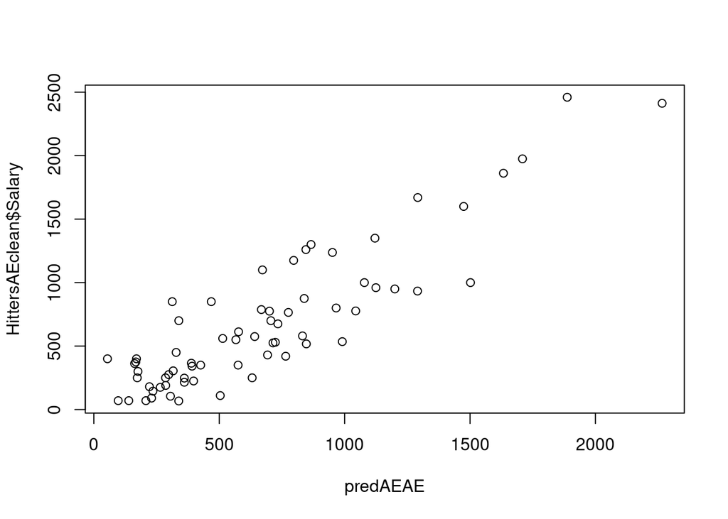

```r
I1<-HittersAEclean.lars$Cp==min(HittersAEclean.lars$Cp)
s1choice<-(c(1:length(I1))[I1])[1]
predAEAE<-predict(HittersAEclean.lars,as.matrix(HittersAEclean[,-c(20,19,14,15)]),s1choice)$fit
predAEAW<-predict(HittersAEclean.lars,as.matrix(HittersAWclean[,-c(20,19,14,15)]),s1choice)$fit
predAENE<-predict(HittersAEclean.lars,as.matrix(HittersNEclean[,-c(20,19,14,15)]),s1choice)$fit
predAENW<-predict(HittersAEclean.lars,as.matrix(HittersNWclean[,-c(20,19,14,15)]),s1choice)$fit
plot(predAEAE, HittersAEclean$Salary)
```

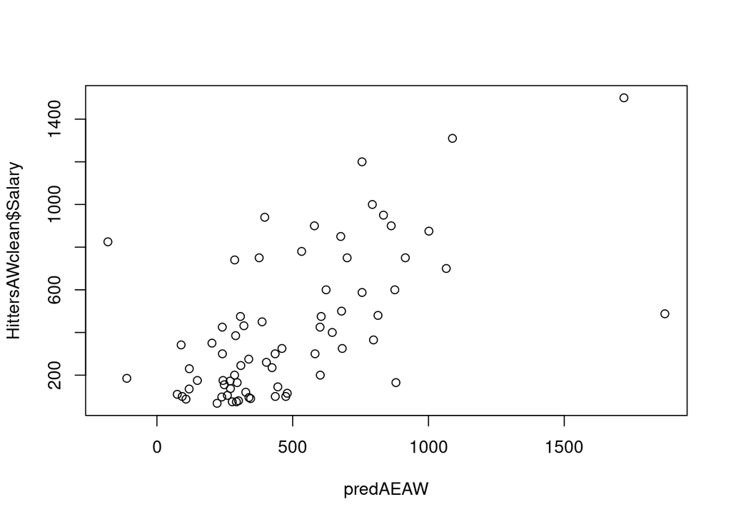

```r
plot(predAEAW, HittersAWclean$Salary)
```

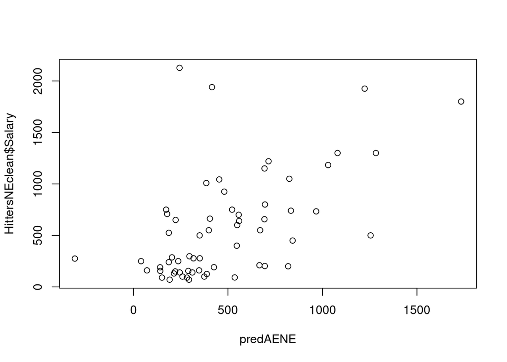

```r
plot(predAENE, HittersNEclean$Salary)
```

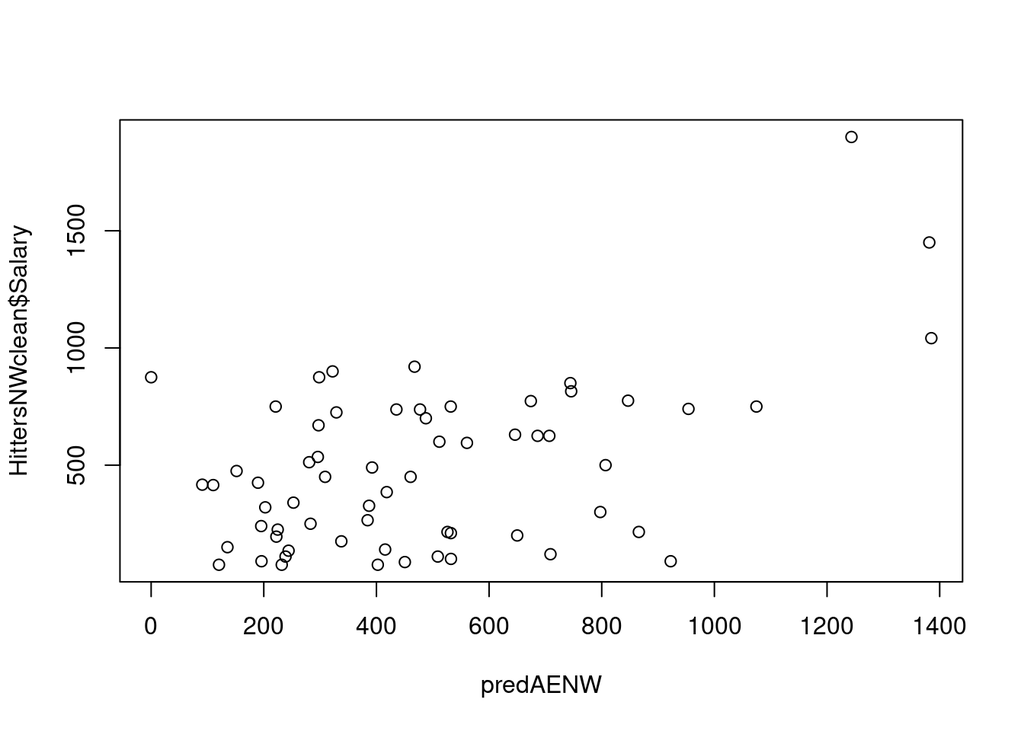

```r
plot(predAENW, HittersNWclean$Salary)
```

# I2

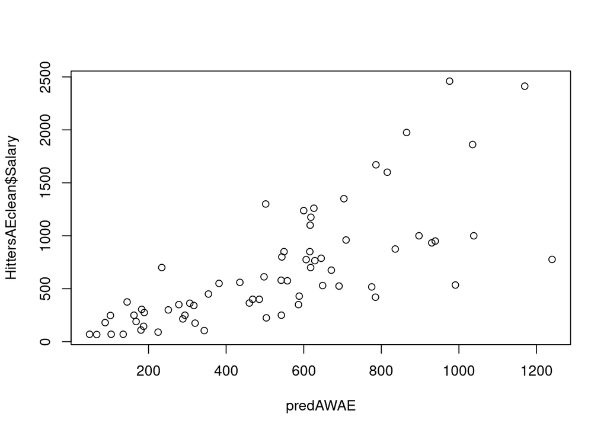

```r
I2 <- HittersAWclean.lars$Cp == min(HittersAWclean.lars$Cp)
s2choice <- (c(1:length(I2))[I2])[1]
predAWAE<-predict(HittersAWclean.lars,as.matrix(HittersAEclean[,-c(20,19,14,15)]),s2choice)$fit
predAWAW<-predict(HittersAWclean.lars,as.matrix(HittersAWclean[,-c(20,19,14,15)]),s2choice)$fit
predAWNE<-predict(HittersAWclean.lars,as.matrix(HittersNEclean[,-c(20,19,14,15)]),s2choice)$fit
predAWNW<-predict(HittersAWclean.lars,as.matrix(HittersNWclean[,-c(20,19,14,15)]),s2choice)$fit

plot(predAWAE, HittersAEclean$Salary)
```

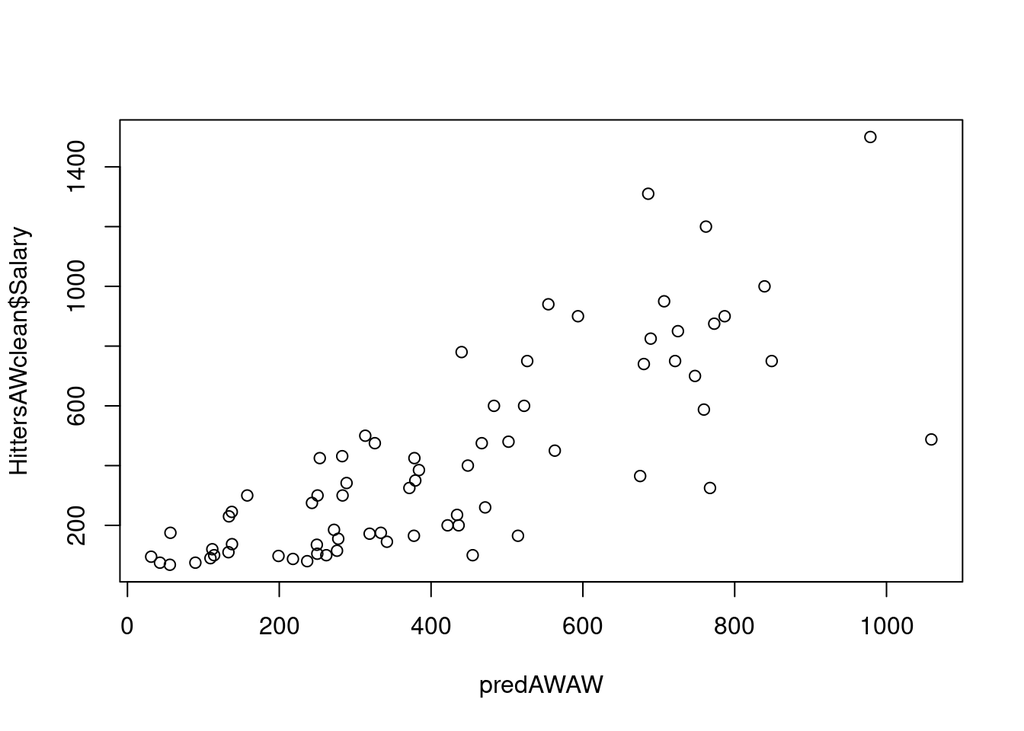

```r
plot(predAWAW, HittersAWclean$Salary)
```

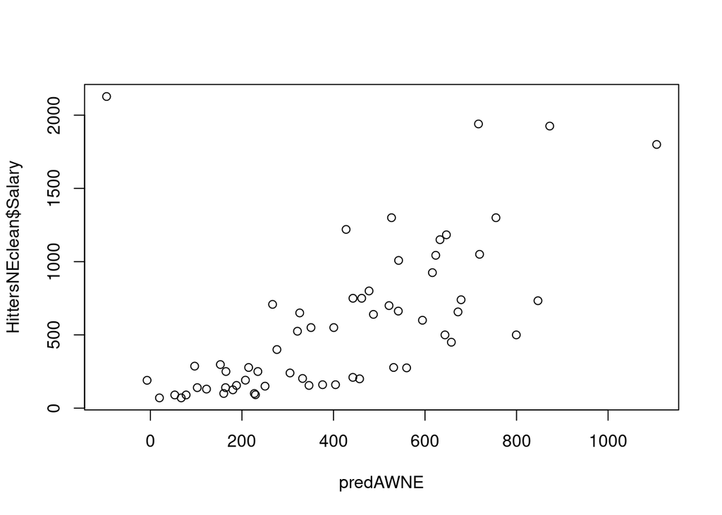

```r
plot(predAWNE, HittersNEclean$Salary)
```

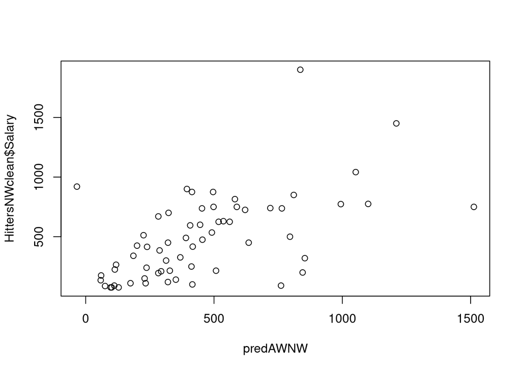

```r
plot(predAWNW, HittersNWclean$Salary)
```

# I3

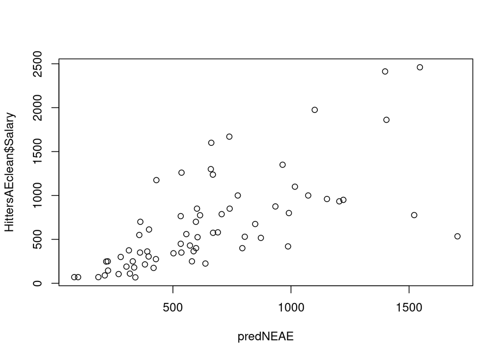

```r
I3 <- HittersNEclean.lars$Cp == min(HittersNEclean.lars$Cp)
s3choice <- (c(1:length(I3))[I3])[1]
predNEAE<-predict(HittersNEclean.lars,as.matrix(HittersAEclean[,-c(20,19,14,15)]),s3choice)$fit
predNEAW<-predict(HittersNEclean.lars,as.matrix(HittersAWclean[,-c(20,19,14,15)]),s3choice)$fit
predNENE<-predict(HittersNEclean.lars,as.matrix(HittersNEclean[,-c(20,19,14,15)]),s3choice)$fit
predNENW<-predict(HittersNEclean.lars,as.matrix(HittersNWclean[,-c(20,19,14,15)]),s3choice)$fit

plot(predNEAE, HittersAEclean$Salary)
```

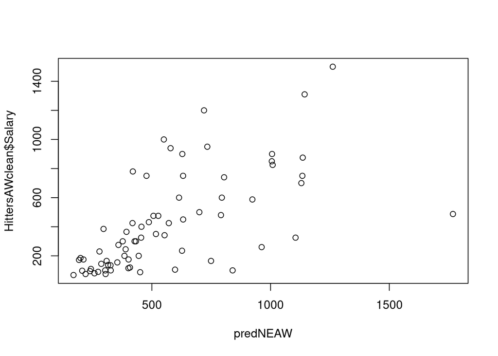

```r
plot(predNEAW, HittersAWclean$Salary)
```

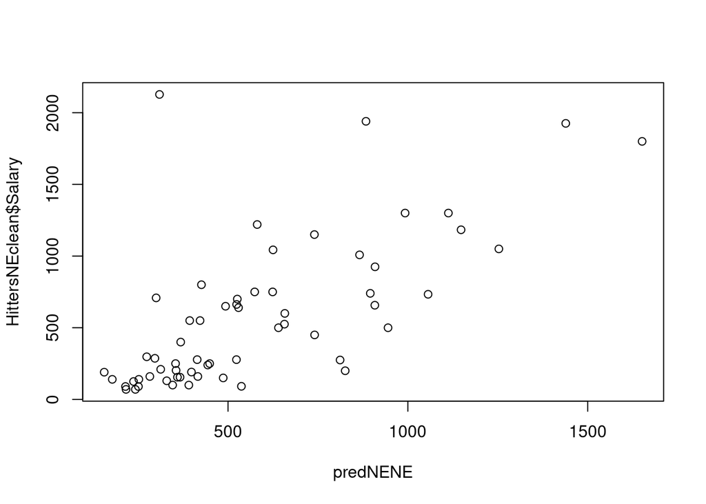

```r
plot(predNENE, HittersNEclean$Salary)
```

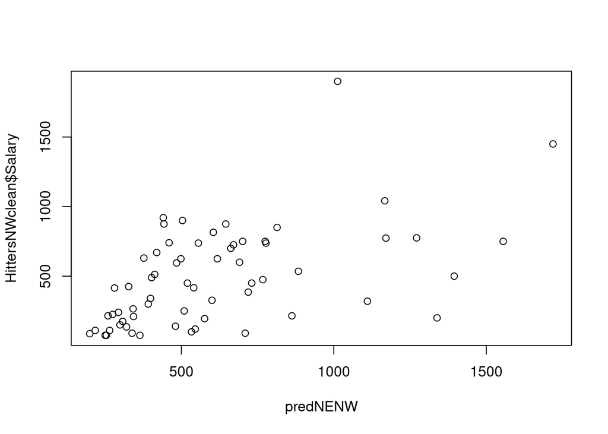

```r
plot(predNENW, HittersNWclean$Salary)
```

# I4

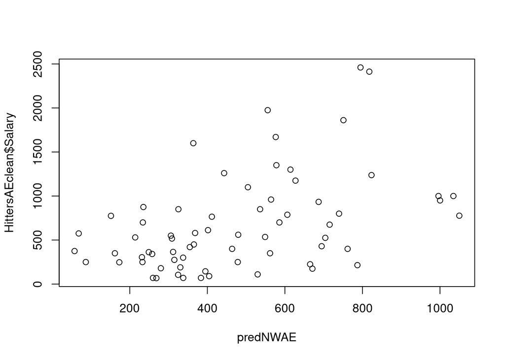

```r
I4 <- HittersNWclean.lars$Cp == min(HittersNWclean.lars$Cp)
s4choice <- (c(1:length(I4))[I4])[1]
predNWAE<-predict(HittersNWclean.lars,as.matrix(HittersAEclean[,-c(20,19,14,15)]),s4choice)$fit
predNWAW<-predict(HittersNWclean.lars,as.matrix(HittersAWclean[,-c(20,19,14,15)]),s4choice)$fit
predNWNE<-predict(HittersNWclean.lars,as.matrix(HittersNEclean[,-c(20,19,14,15)]),s4choice)$fit
predNWNW<-predict(HittersNWclean.lars,as.matrix(HittersNWclean[,-c(20,19,14,15)]),s4choice)$fit

plot(predNWAE, HittersAEclean$Salary)
```

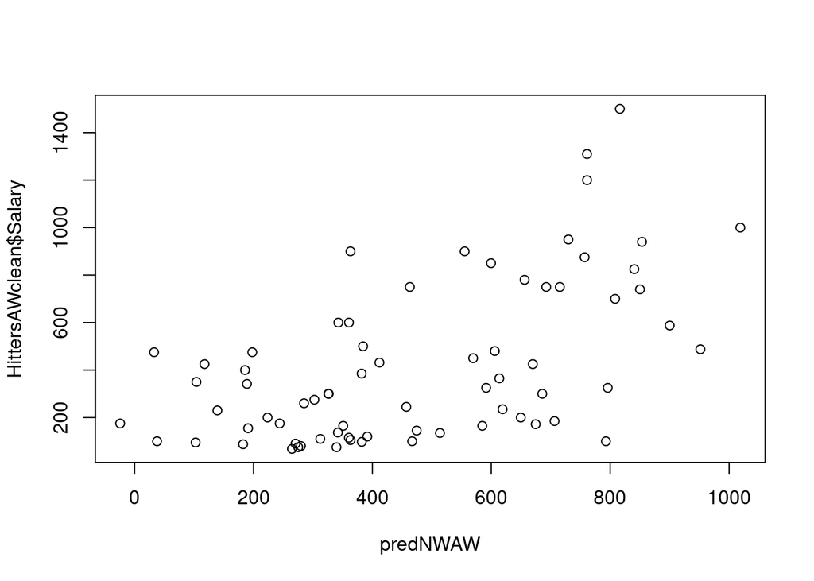

```r
plot(predNWAW, HittersAWclean$Salary)
```

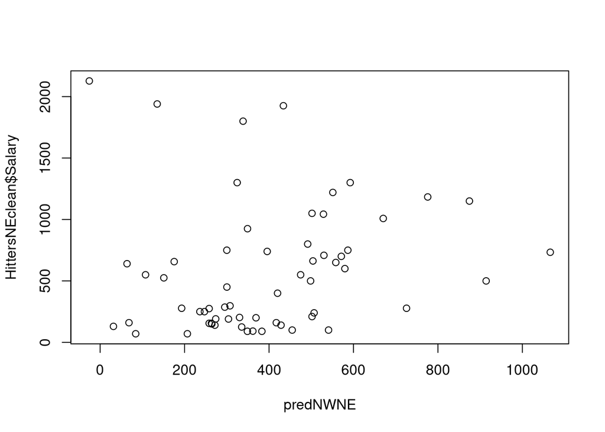

```r
plot(predNWNE, HittersNEclean$Salary)
```

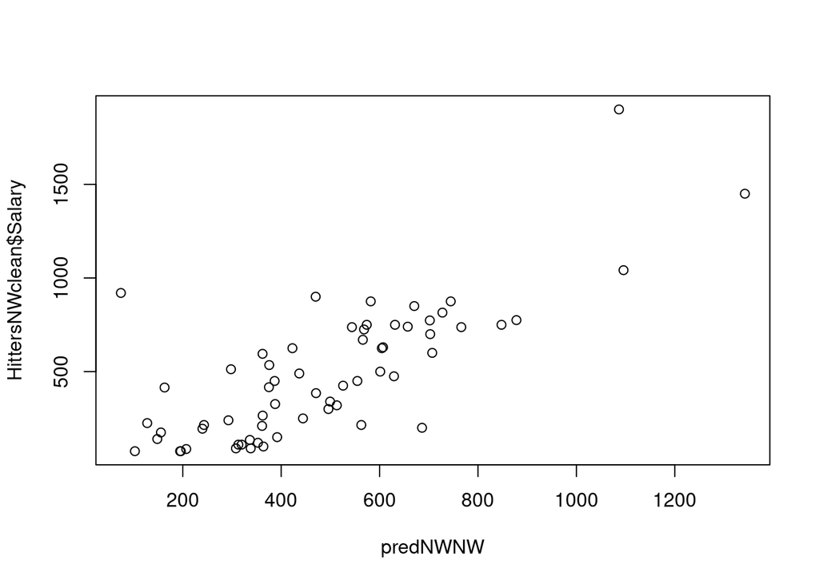

```r
plot(predNWNW, HittersNWclean$Salary)
```

# LARS Observations

```r
betalarsAE<-HittersAEclean.lars$beta[I1]
IAE<-betalarsAE!=0
HittersAEcleanforlm<-HittersAEclean[,-c(20,19,14,15)][,IAE]
HittersAEcleanforlm<-cbind.data.frame(HittersAEcleanforlm, HittersAEclean$Salary)
dimnames(HittersAEcleanforlm)[[2]][13]<-"Salary"
HittersAElm<-lm(Salary~.,data = HittersAEcleanforlm)
predlmAE<-predict(HittersAElm)

summary(HittersAElm)
```

```
##
## Call:
## lm(formula = Salary ~ ., data = HittersAEcleanforlm)
##
## Residuals:
##     Min      1Q  Median      3Q     Max
## -523.01 -161.61  -38.52  161.89  585.75
##
## Coefficients:
##              Estimate Std. Error t value Pr(>|t|)
## (Intercept) 333.91615  132.24513   2.525 0.014484 *
## AtBat        -3.77014    1.07858  -3.495 0.000943 ***
## Hits         10.47129    2.91559   3.591 0.000702 ***
## HmRun        -4.36881    6.70363  -0.652 0.517304
## Runs          1.89356    5.20378   0.364 0.717341
## Walks         6.28731    2.97286   2.115 0.038984 *
## CAtBat       -0.50438    0.14549  -3.467 0.001030 **
## CHmRun       -0.08326    2.50097  -0.033 0.973562
## CRuns         3.66894    0.86701   4.232 8.86e-05 ***
## CRBI          1.52229    1.06146   1.434 0.157194
## CWalks       -1.33811    0.41962  -3.189 0.002359 **
## PutOuts       0.38200    0.13641   2.800 0.007027 **
## Assists       0.25849    0.31141   0.830 0.410091
## ---
## Signif. codes:  0 '***' 0.001 '**' 0.01 '*' 0.05 '.' 0.1 ' ' 1
##
## Residual standard error: 271.9 on 55 degrees of freedom
## Multiple R-squared:  0.7945, Adjusted R-squared:  0.7496
## F-statistic: 17.72 on 12 and 55 DF,  p-value: 9.215e-15
```

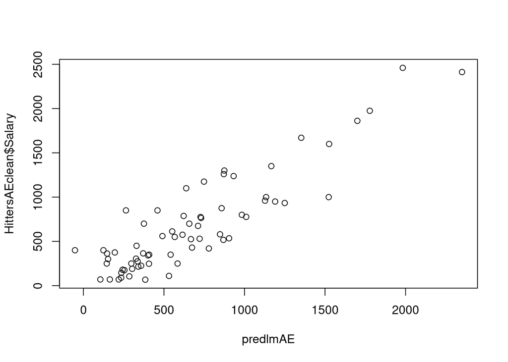

```r
plot(predlmAE, HittersAEclean$Salary)
```

```r
HittersAEclean.lars$beta
```

```
##         AtBat       Hits     HmRun      Runs       RBI    Walks       Years
## 0   0.0000000  0.0000000  0.000000 0.0000000 0.0000000 0.000000   0.0000000
## 1   0.0000000  0.0000000  0.000000 0.0000000 0.0000000 0.000000   0.0000000
## 2   0.0000000  0.8122616  0.000000 0.0000000 0.0000000 0.000000   0.0000000
## 3   0.0000000  2.0186983  0.000000 0.0000000 0.0000000 1.440372   0.0000000
## 4   0.0000000  2.7909230  0.000000 0.0000000 0.0000000 2.077594   0.0000000
## 5   0.0000000  2.9971448  0.000000 0.0000000 0.0000000 2.258684   0.0000000
## 6   0.0000000  3.5068816  0.000000 0.0000000 0.0000000 2.233706   0.0000000
## 7   0.0000000  3.7379794  0.000000 0.0000000 0.0000000 2.360107   0.0000000
## 8   0.0000000  3.7278504  0.000000 0.0000000 0.0000000 2.356193  -1.0147514
## 9   0.0000000  4.1108381 -4.649594 0.0000000 0.0000000 2.373007 -14.8054215
## 10 -0.3724494  5.0690336 -4.643616 0.0000000 0.0000000 2.525182 -17.3675485
## 11 -0.8335450  6.0694983 -4.657422 0.0000000 0.0000000 3.266497 -18.0548770
## 12 -1.2168187  6.7087620 -4.996562 0.5535345 0.0000000 3.705989 -18.6114161
## 13 -2.7666009  9.0559254 -6.311730 3.2888704 0.0000000 5.400874 -22.3358204
```

[output cut: 61 more lines]

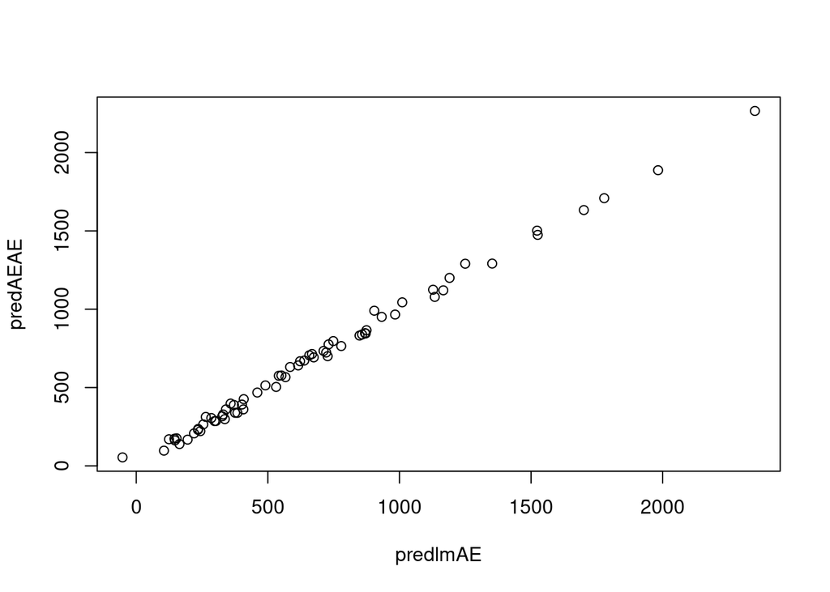

```r
plot(predlmAE, predAEAE)
```

```r
betalarsAW<-HittersAWclean.lars$beta[I2]
IAE<-betalarsAE!=0
HittersAWcleanforlm<-HittersAWclean[,-c(20,19,14,15)][,IAE]
HittersAWcleanforlm<-cbind.data.frame(HittersAWcleanforlm, HittersAWclean$Salary)
dimnames(HittersAWcleanforlm)[[2]][13]<-"Salary"
HittersAWlm<-lm(Salary~.,data = HittersAWcleanforlm)
predlmAW<-predict(HittersAWlm)

summary(HittersAWlm)
```

```
##
## Call:
## lm(formula = Salary ~ ., data = HittersAWcleanforlm)
##
## Residuals:
##     Min      1Q  Median      3Q     Max
## -432.19 -103.63    4.12  113.24  561.41
##
## Coefficients:
##              Estimate Std. Error t value Pr(>|t|)
## (Intercept) -74.68235   91.77696  -0.814   0.4191
## AtBat        -1.08876    0.80651  -1.350   0.1823
## Hits          6.13144    3.37133   1.819   0.0741 .
## HmRun         8.23297    4.85858   1.695   0.0955 .
## Runs         -4.89303    4.47106  -1.094   0.2783
## Walks         4.45239    2.42042   1.840   0.0710 .
## CAtBat       -0.02447    0.10646  -0.230   0.8190
## CHmRun       -1.59079    1.47853  -1.076   0.2864
## CRuns         1.60826    0.73560   2.186   0.0328 *
## CRBI         -0.14970    0.71698  -0.209   0.8353
## CWalks       -0.37717    0.37174  -1.015   0.3145
## PutOuts       0.13037    0.10907   1.195   0.2368
## Assists       0.17264    0.22290   0.775   0.4418
## ---
## Signif. codes:  0 '***' 0.001 '**' 0.01 '*' 0.05 '.' 0.1 ' ' 1
##
## Residual standard error: 214.1 on 58 degrees of freedom
## Multiple R-squared:  0.6597, Adjusted R-squared:  0.5893
## F-statistic: 9.368 on 12 and 58 DF,  p-value: 1.011e-09
```

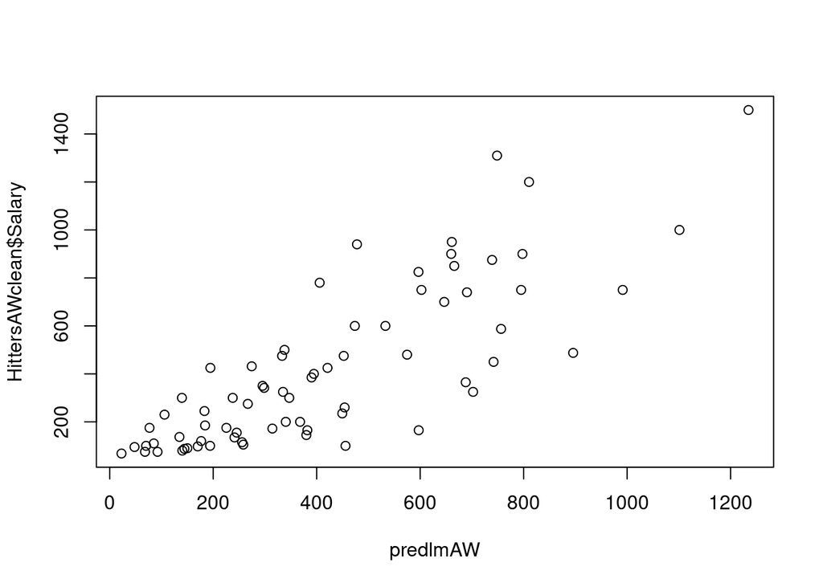

```r
plot(predlmAW, HittersAWclean$Salary)
```

```r
HittersAWclean.lars$beta
```

```
##         AtBat     Hits    HmRun      Runs        RBI     Walks       Years
## 0   0.0000000 0.000000 0.000000  0.000000  0.0000000 0.0000000   0.0000000
## 1   0.0000000 0.000000 0.000000  0.000000  0.0000000 0.0000000   0.0000000
## 2   0.0000000 1.694400 0.000000  0.000000  0.0000000 0.0000000   0.0000000
## 3   0.0000000 2.054081 0.000000  0.000000  0.0000000 0.5716065   0.0000000
## 4   0.0000000 2.302434 0.000000  0.000000  0.0000000 1.0376837   0.0000000
## 5   0.0000000 2.259070 0.000000  0.000000  0.0000000 1.2339567   0.0000000
## 6   0.0000000 1.958611 1.654430  0.000000  0.0000000 1.6362667   0.0000000
## 7   0.0000000 1.888319 1.802738  0.000000  0.0000000 1.7778614   0.0000000
## 8   0.0000000 1.865702 1.852362  0.000000  0.0000000 1.8201040   0.0000000
## 9   0.0000000 1.853898 1.871440  0.000000  0.0000000 1.8307034  -0.2067729
## 10  0.0000000 1.707597 2.236743  0.000000  0.0000000 1.9013929  -2.0416251
## 11 -0.1897395 2.025529 3.065739  0.000000  0.0000000 2.0945537  -4.8525743
## 12 -0.4007464 2.500082 4.926469  0.000000 -0.5476560 2.3921088  -7.7090820
## 13 -0.5906812 3.582673 6.923304 -1.394269 -1.0396840 3.0980757  -8.9875563
```

[output cut: 55 more lines]

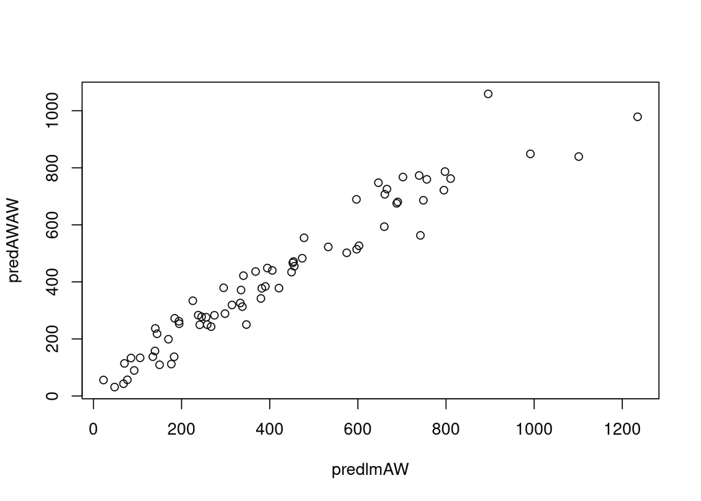

```r
plot(predlmAW, predAWAW)
```

```r
betalarsNE<-HittersNEclean.lars$beta[I3]
INE<-betalarsNE!=0
HittersNEcleanforlm<-HittersNEclean[,-c(20,19,14,15)][,IAE]
HittersNEcleanforlm<-cbind.data.frame(HittersNEcleanforlm, HittersNEclean$Salary)
dimnames(HittersNEcleanforlm)[[2]][13]<-"Salary"
HittersNElm<-lm(Salary~.,data = HittersNEcleanforlm)
predlmNE<-predict(HittersNElm)

summary(HittersNElm)
```

```
##
## Call:
## lm(formula = Salary ~ ., data = HittersNEcleanforlm)
##
## Residuals:
##     Min      1Q  Median      3Q     Max
## -655.91 -174.45 -105.54   78.81 1665.71
##
## Coefficients:
##              Estimate Std. Error t value Pr(>|t|)
## (Intercept) 241.56135  170.35467   1.418   0.1627
## AtBat        -1.92080    1.63931  -1.172   0.2471
## Hits         -0.20011    6.31043  -0.032   0.9748
## HmRun        -0.51651   13.29210  -0.039   0.9692
## Runs          5.50234    6.59818   0.834   0.4085
## Walks         6.54413    5.46424   1.198   0.2369
## CAtBat       -0.09499    0.20047  -0.474   0.6377
## CHmRun       -3.48272    3.56442  -0.977   0.3334
## CRuns         0.71779    1.17204   0.612   0.5431
## CRBI          2.65793    1.45266   1.830   0.0735 .
## CWalks       -1.15642    0.97134  -1.191   0.2397
## PutOuts       0.44904    0.21573   2.082   0.0427 *
## Assists       0.98283    0.44849   2.191   0.0333 *
## ---
## Signif. codes:  0 '***' 0.001 '**' 0.01 '*' 0.05 '.' 0.1 ' ' 1
##
## Residual standard error: 403.9 on 48 degrees of freedom
## Multiple R-squared:  0.4975, Adjusted R-squared:  0.3719
## F-statistic:  3.96 on 12 and 48 DF,  p-value: 0.0003011
```

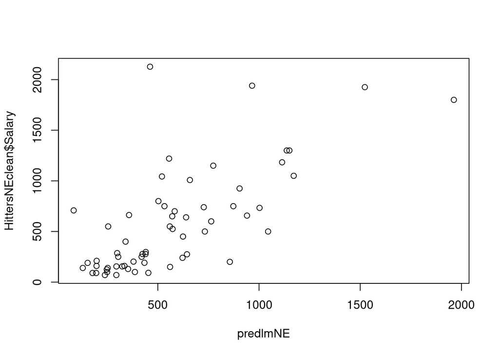

```r
plot(predlmNE, HittersNEclean$Salary)
```

```r
HittersNEclean.lars$beta
```

```
##         AtBat        Hits      HmRun      Runs        RBI    Walks      Years
## 0   0.0000000  0.00000000  0.0000000 0.0000000  0.0000000 0.000000   0.000000
## 1   0.0000000  0.00000000  0.0000000 0.0000000  0.0000000 0.000000   0.000000
## 2   0.0000000  0.00000000  0.0000000 0.0000000  0.0000000 0.000000   0.000000
## 3   0.0000000  0.00000000  0.0000000 0.0000000  0.0000000 1.289593   0.000000
## 4   0.0000000  0.00000000  0.0000000 0.0000000  0.0000000 1.490371   0.000000
## 5   0.0000000  0.00000000  0.0000000 0.0000000  0.0000000 1.547594   0.000000
## 6   0.0000000  0.00000000  0.0000000 0.0000000  0.0000000 1.481777   0.000000
## 7  -0.2091784  0.00000000  0.0000000 0.0000000  0.0000000 2.371028   0.000000
## 8  -0.2481822  0.00000000  0.0000000 0.0000000  0.0000000 2.532354   0.000000
## 9  -0.3194635  0.00000000  0.0000000 0.4031221  0.0000000 2.526545   0.000000
## 10 -0.4525771  0.00000000  0.0000000 0.9929174  0.0000000 2.588711  -3.902590
## 11 -0.4589297  0.00000000  0.0000000 1.0122504  0.0000000 2.594852  -4.229622
## 12 -0.6752657  0.00000000  0.0000000 1.4459578  0.4837123 2.793213 -12.850016
## 13 -0.9649174  0.00000000 -3.2482999 2.0493007  1.8504779 2.849239 -23.472669
```

[output cut: 73 more lines]

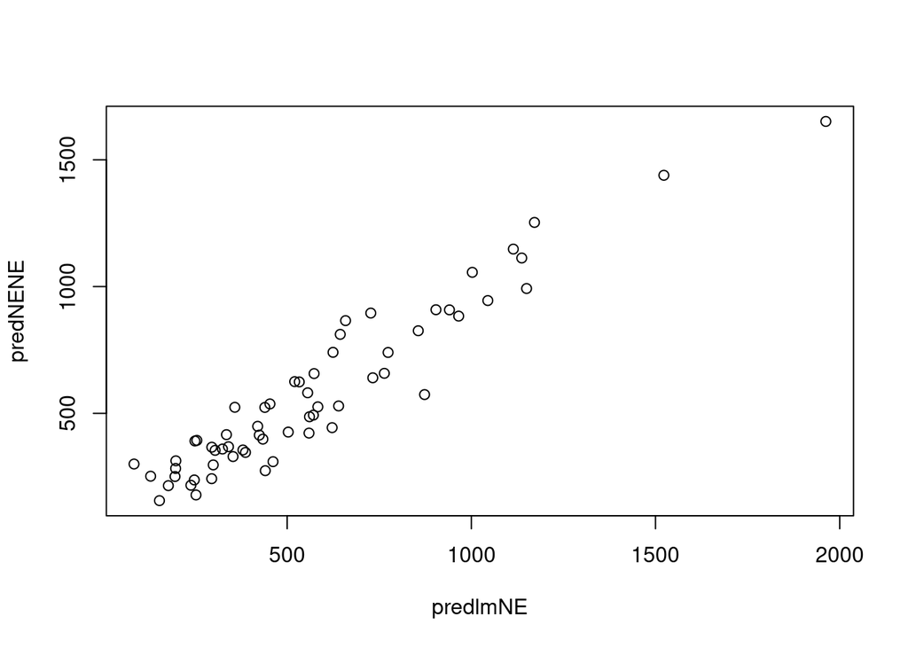

```r
plot(predlmNE, predNENE)
```

```r
betalarsNW<-HittersNWclean.lars$beta[I4]
IAE<-betalarsAE!=0
HittersNWcleanforlm<-HittersNWclean[,-c(20,19,14,15)][,IAE]
HittersNWcleanforlm<-cbind.data.frame(HittersNWcleanforlm, HittersNWclean$Salary)
dimnames(HittersNWcleanforlm)[[2]][13]<-"Salary"
HittersNWlm<-lm(Salary~.,data = HittersNWcleanforlm)
predlmNW<-predict(HittersNWlm)

summary(HittersNWlm)
```

```
##
## Call:
## lm(formula = Salary ~ ., data = HittersNWcleanforlm)
##
## Residuals:
##     Min      1Q  Median      3Q     Max
## -582.60 -135.57  -52.55  116.09  865.50
##
## Coefficients:
##              Estimate Std. Error t value Pr(>|t|)
## (Intercept)  92.54282  115.58292   0.801   0.4271
## AtBat         0.45483    1.41273   0.322   0.7488
## Hits          2.00620    4.61386   0.435   0.6656
## HmRun         6.50579   10.27662   0.633   0.5296
## Runs         -9.42023    5.08157  -1.854   0.0697 .
## Walks         8.37408    3.44335   2.432   0.0186 *
## CAtBat        0.10476    0.15466   0.677   0.5013
## CHmRun        2.01152    1.98538   1.013   0.3159
## CRuns         0.82996    0.81791   1.015   0.3151
## CRBI         -0.59917    0.83086  -0.721   0.4742
## CWalks       -1.45782    0.61768  -2.360   0.0222 *
## PutOuts       0.05704    0.15132   0.377   0.7078
## Assists      -0.55525    0.37190  -1.493   0.1417
## ---
## Signif. codes:  0 '***' 0.001 '**' 0.01 '*' 0.05 '.' 0.1 ' ' 1
##
## Residual standard error: 277 on 50 degrees of freedom
## Multiple R-squared:  0.501,  Adjusted R-squared:  0.3812
## F-statistic: 4.183 on 12 and 50 DF,  p-value: 0.000156
```

```r
coefficients_lars <- HittersAEclean.lars$beta[I1]
coef_table <- as.data.frame(t(coefficients_lars))
print(coef_table)
```

```
##       V1      V2        V3      V4 V5       V6 V7         V8 V9       V10
## 1 -3.353 10.0477 -5.187081 1.92523  0 6.160729  0 -0.3771068  0 0.8418551
##        V11      V12       V13       V14       V15 V16
## 1 2.948038 1.014535 -1.176006 0.3408382 0.1259118   0
```

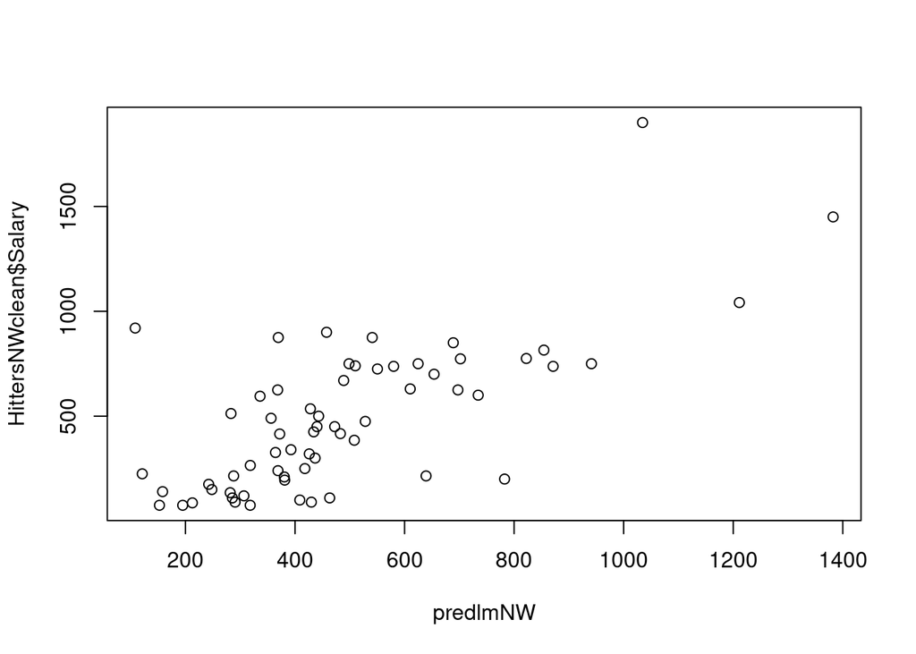

```r
plot(predlmNW, HittersNWclean$Salary)
```

```r
HittersNWclean.lars$beta
```

```
##         AtBat     Hits     HmRun        Runs         RBI     Walks     Years
## 0  0.00000000 0.000000  0.000000   0.0000000   0.0000000 0.0000000  0.000000
## 1  0.00000000 0.000000  0.000000   0.0000000   0.0000000 0.0000000  0.000000
## 2  0.00000000 0.000000  0.000000   0.0000000   0.0000000 0.0000000  0.000000
## 3  0.00000000 0.000000  0.000000   0.0000000   0.0000000 0.0000000  0.000000
## 4  0.03836443 0.000000  0.000000   0.0000000   0.0000000 0.0000000  0.000000
## 5  0.08333173 0.000000  0.000000   0.0000000   0.0000000 0.0000000  0.000000
## 6  0.21027591 0.000000  4.189280   0.0000000   0.0000000 0.0000000  0.000000
## 7  0.21058076 0.000000  4.195875   0.0000000   0.0000000 0.0000000  0.000000
## 8  0.21050969 0.000000  5.491444   0.0000000   0.0000000 0.6194862  0.000000
## 9  0.21764506 0.000000  5.772419   0.0000000   0.0000000 0.7499560  1.165483
## 10 0.45273589 0.000000  3.360270   0.0000000   0.0000000 1.4374132  7.088334
## 11 0.45785448 0.000000  3.279302   0.0000000   0.0000000 1.4794759  7.289705
## 12 0.51196078 0.000000  3.626981  -0.4336972   0.0000000 1.5907875  7.031636
## 13 0.60466802 0.000000  5.009483  -0.8717271  -0.5427673 1.6723062  6.992906
```

[output cut: 61 more lines]

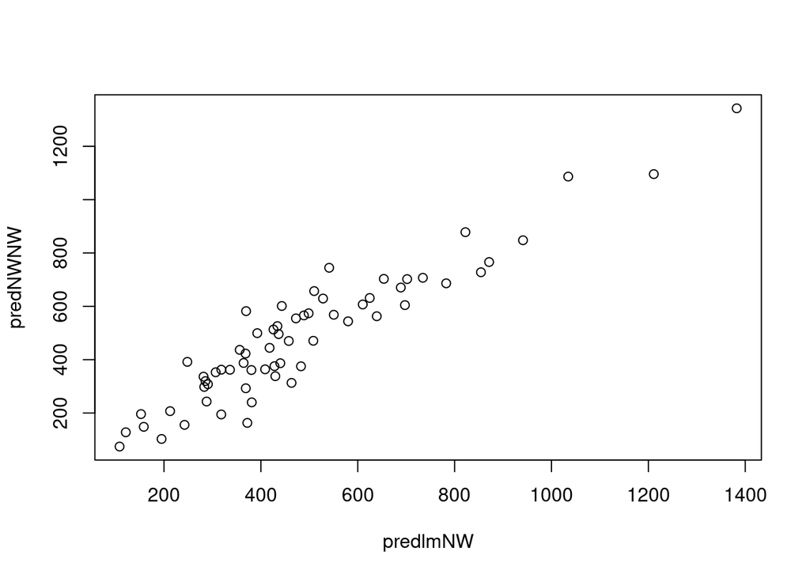

```r
plot(predlmNW, predNWNW)
```

# Discussion Questions

*Is there a difference in distributions of salaries between the 4 divisions?*

- Yes there is a difference in distributions of the salaries between 4 divisions, there is no single multicollinearity between all divisions.

*Is there a difference in the way salary depends on performance between the 4 divisions? 1 look at all 4 divisions*

- There is an observed difference in the way salary depends on performance between the 4 divisions. In general, heteroscedascity is observed among all plots.

*2 For each division choose the minimal Cp lars model (20 points each division, 80 points total)*

- The division with the minimal CP lars model is AE.

*Check with scatterplots the predictions using the minimal CP lars model from the chosen division against actual salaries for each division (4 scatterplots, construct 4 predictions based on the 1 model ). After you do this for all 4 divisions (16 scatterplots) Use this to decide if it looks like there is a uniform process based on performance for choosing salary or not. Argue why or why not.*

- I do not think there is a uniform process. If there was a uniform process based on performance than there should be no variation between players having a linear relationship between all divisions, rather there are extreme outliers indicating that there is no uniformity between the grpahs.

*3 After youve done steo 2 building the lars model 4 times (so 16 plots) compare the lars and lm model for the same variables predicting the salary for 1 division (1 scatterplot) (20 points)*

- The relationship between the predicted AE and lmAE graphs shows an almost perfect linear relationship.

*Compare the prediction (eg. just AElars vs AElm) and the coefficients. What have the coefficients done between Lars and LM???*

- Between the two graphs, holding all other variables constant, both AElars and AElm have similar coefficients, i.e. Hits (10.0477, 10.47129) respectively. This means that both have similar coefficients so that at each unit increase allows for each coefficient to affect each players wage similarly thus allowing for an almost perfect linear relationship between the two graphs.